# Class 15: Using AWS Instances

Working with your own computer in the cloud (Part 2)

Author

Barry Grant

Published

November 14, 2022

Modified

November 18, 2026

## 1. Background

The goal of this hands-on session is to run you through a demonstration of using the command line on an Amazon Web Service (AWS) (Figure 1) instance to do some familiar bioinformatics analysis.

Our previous Section 1 of this lab covered how to launch your own [AWS](https://aws.amazon.com/ec2/) Elastic Compute Cloud (a.k.a. EC2) virtual machine *instance* and connect to it via **SSH**. You will need to have completed that section before you can do this one.

[figure not shown]

Figure 1: AWS is currently the most popular cloud compute provider.

**Where am I?** In this lab you will type commands in two places. Each code block is labelled **On AWS** (your remote instance, where the prompt starts with `ubuntu@`) or **On your laptop** (a terminal on your own computer). Check the label before you paste!

**Questions** are numbered **Q1** to **Q10**. Record your answers to all of them in your own Quarto lab report (i.e. the notes text file we started in the last Section in your `class15` directory).

## 2. Software Update

At this point what you have connected to is effectively a brand new machine (with a fresh **Ubuntu Linux OS** just installed).

Like any new machine it is a good idea to first refresh the list of available software so that we install the latest and greatest versions of the various software we will need later.

Copy and paste the following two commands into your AWS instance command line to update the software list and then install NCBI BLAST+:

```
On AWS
```

```bash
sudo apt-get update
sudo apt-get -y install ncbi-blast+
```

> **Side-note**: Please make sure to hit enter after the paste – sometimes the last line doesn’t paste completely. If you are using Git Bash on windows you will need to `right-click` inside the terminal window and select `Paste`. Standard `Ctrl + V` does not work by default because Bash reserves it for inserting literal characters. On some versions you can use `Ctrl + Shift + C` to copy and `Ctrl + Shift + V` to paste.

The **apt-get** command is used to find, install and upgrade software packages on Debian based Linux machines like the one you are using here.

The **sudo** in-front of these commands gives us administrator (or in UNIX speak ‘superuser’) permissions to install packages that a normal user does not have. The name **sudo** stands for “superuser do” as the early versions of sudo were designed to run commands only as the superuser.

> **Side-note**: If you are using a Mac laptop ask Barry about the **homebrew** package manager for that OS which can do much of the same as **apt-get** but on a Mac. It is super useful! On Windows the closest equivalents are **winget** and **scoop** (homebrew itself only runs on Windows inside WSL, the Windows Subsystem for Linux).

## 3. Download Sequences

Now we need some data to play with! Let’s grab the mouse and zebrafish RefSeq protein data sets from NCBI, and put them in a new directory that we will create called `work`. If you’ve just logged in, you should be in your home area already, but if you’re unsure, just run `cd` by itself and hit enter.

```
On AWS
```

```bash
cd
mkdir work
cd work
```

Check you are where you think you are (i.e. in `/home/ubuntu/work`) with the **P**rint **W**orking **D**irectory command, **pwd**:

```
On AWS
```

```bash
pwd
```

Now, we’ll use `curl` to download the files:

```
On AWS
```

```bash
curl -O https://ftp.ncbi.nlm.nih.gov/refseq/M_musculus/mRNA_Prot/mouse.1.protein.faa.gz

curl -O https://ftp.ncbi.nlm.nih.gov/refseq/M_musculus/mRNA_Prot/mouse.2.protein.faa.gz

curl -O https://ftp.ncbi.nlm.nih.gov/refseq/D_rerio/mRNA_Prot/zebrafish.1.protein.faa.gz
```

## 4. Inspect Sequences

If you look at the files in the current directory, you should see three files:

```
On AWS
```

```bash
ls -l
```

should show you something like (your dates and file sizes will differ):

```
total 31416
-rw-rw-r-- 1 ubuntu ubuntu 11349404 Nov 20 20:16 mouse.1.protein.faa.gz
-rw-rw-r-- 1 ubuntu ubuntu  6867542 Nov 20 20:17 mouse.2.protein.faa.gz
-rw-rw-r-- 1 ubuntu ubuntu 13947543 Nov 20 20:17 zebrafish.1.protein.faa.gz
```

All three files are FASTA protein files (that’s what the .faa suggests) that are compressed with `gzip` (that’s what the .gz means).

Uncompress them:

```
On AWS
```

```bash
gunzip *.faa.gz
```

**Q1**. What does the star character accomplish in `gunzip *.faa.gz` command here? Ask Barry, or your class neighbor, if you are not sure!

Now let’s look at the first few sequences in one of the files:

```
On AWS
```

```bash
head mouse.1.protein.faa
```

These are protein sequences in FASTA format. FASTA format is something many of you have probably seen in one form or another – it’s pretty ubiquitous. It’s a text file, containing records; each record starts with a line beginning with a ‘>’, and then contains one or more lines of sequence text.

**Q2**. How many sequences are in this `mouse.1.protein.faa` file? Hint: Try using **grep** to figure this out…

Let’s take the first two sequences and save them to a new file that we will create called `mm-first.fa`. We’ll do this using output redirection with ‘>’, which says “take all the output and put it into this file here.”

```
On AWS
```

```bash
head -11 mouse.1.protein.faa > mm-first.fa
```

**Side-note**: `head -11` cuts by *line number*, so it only gives exactly two sequences if those two records happen to fill the first 11 lines. NCBI updates these files regularly, so check with `grep -c ">" mm-first.fa` (it should report 2). A way of taking the first two *records* that does not depend on line numbers is:

```
On AWS
```

```bash
awk '/^>/{n++} n>2{exit} 1' mouse.1.protein.faa > mm-first.fa
```

**Q3**. What happens if you run the above `head` command without the `> mm-first.fa` part?

**Q4**. What happens if you were to use two ‘>’ symbols (i.e. `>> mm-first.fa`)?

You can do `less mm-first.fa` to see the contents of that file (or `more mm-first.fa`). Type space-bar to move down and ‘q’ to get out of paging mode.

Make sure you have run the correct command above with the one ‘>’ symbol so you only have two sequences in your new file.

Now let’s BLAST these two sequences against the entire zebrafish protein data set. First, we need to tell BLAST that the zebrafish sequences are (a) a database, and (b) a protein database. That’s done by calling `makeblastdb`:

```
On AWS
```

```bash
makeblastdb -in zebrafish.1.protein.faa -dbtype prot
```

## 5. Running command line BLAST

Next, we call protein BLAST (`blastp`) to do the search:

```
On AWS
```

```bash
blastp -query mm-first.fa -db zebrafish.1.protein.faa
```

This should run pretty quickly, but you’re going to get a lot of output!! To save it to a file instead of watching it go past on the screen, ask BLAST to save the output to a file that we’ll name `mm-first.x.zebrafish.txt`:

```
On AWS
```

```bash
blastp -query mm-first.fa -db zebrafish.1.protein.faa -out mm-first.x.zebrafish.txt
```

and then you can ‘page’ through this file at your leisure by typing:

```
On AWS
```

```bash
less mm-first.x.zebrafish.txt
```

(Type `spacebar` to move down, and `q` to get out of paging mode.)

## 6. Running more BLAST jobs

Let’s do some more sequences (this one will take a little longer to run):

```
On AWS
```

```bash
head -497 mouse.1.protein.faa > mm-second.fa
```

**Q5**. How would you determine how many sequences are in the `mm-second.fa` file?

Now run BLAST with this file as a query and the zebrafish database

```
On AWS
```

```bash
blastp -query mm-second.fa -db zebrafish.1.protein.faa -out mm-second.x.zebrafish.txt
```

This will compare roughly the first 80 sequences (you worked out the exact number in Q5). You can look at the output file with:

```
On AWS
```

```bash
less mm-second.x.zebrafish.txt
```

(and again, type `q` to get out of paging mode.)

**Try it**: Your instance has 8 CPUs but by default `blastp` only uses one of them. Put `time` in front of the command to see how long it takes, then run it again with the `-num_threads 8` option added. How much faster is it?

**N.B.** If you are using a smaller instance type (e.g. **m7i-flex.large**) then you may not have 8 CPUs available, so adjust the number of threads accordingly. You can also check how many CPUs you have with the command `nproc`.

```
On AWS
```

```bash
time blastp -query mm-second.fa -db zebrafish.1.protein.faa -out mm-second.x.zebrafish.txt -num_threads 8
```

## 7. Producing a TSV output

Last, but not least, let’s generate a more machine-readable version of these results, feel free to add an appropriate `-num_threads` argument if you think it is worth it:

```
On AWS
```

```bash
blastp -query mm-second.fa -db zebrafish.1.protein.faa -out results.tsv -outfmt 6
```

You can open the file with `less results.tsv` to see how the file looks.

See [this link](http://www.metagenomics.wiki/tools/blast/blastn-output-format-6) for a description of the possible BLAST output formats.

## 8. Transfer your results back to your computer

You now have a decision to make: do you want to further analyze your results on this remote machine or transfer your current working results back to your own machine for local analysis. Let’s do the latter first and in so doing demonstrate how to transfer data between your remote AWS instance (i.e. remote server) and your local machine (i.e. your own laptop).

For data transfer we will first demonstrate the use of `scp` for **S**ecure **C**o**P**y.

**Back on your LOCAL machine** in a new terminal go to a directory where you want to store the incoming data. For example, I am working in a directory on my `Desktop` called `class15`

```
On your laptop
```

```bash
# Use a location directory that exists and is meaningful for you!
cd ~/Desktop/class15
```

To save retyping (and typos!) store the location of your key file and the address of your instance in two shell variables, `KEY` and `SERVER`. Use the name of YOUR key file and the address of YOUR instance here, just as we did with our initial login:

```
On your laptop
```

```bash
# Use YOUR key file and YOUR instance address, e.g.
KEY=~/Downloads/bioinf_bjgrant.pem
SERVER=ubuntu@ec2-54-200-207-12.us-west-2.compute.amazonaws.com
```

These variables only exist in this terminal window, so you will need to set them again if you open a new one. You can check them with `echo $KEY $SERVER`.

Now still on *your local machine* use **scp** to transfer the file or files you want copied across:

```
On your laptop
```

```bash
scp -i $KEY $SERVER:~/work/results.tsv .
```

Note. Like **cp** and similar tools, the source is always the first argument, and the destination is always the second argument.

Now you can either jump to *Section 9* and analyze these results on your own computer or, optionally, install R and RStudio on your remote instance and examine them there (Section 10).

## 9. Analyze your results in R

Back on your own machine you can open a new RStudio project where you are typically storing all your class work to date. Start a new quarto document and use it to read your TSV results `results.tsv` file into R.

**Q6**. From reading your results into R how many alignments did we generate statistics for in total?

Tip: Useful functions here will include `read.delim()` and `colnames()` to set the missing column names. Our TSV file has no header line, so we need `header=FALSE` (what happens to the first alignment if you leave this out?).

```r
res <- read.delim( ____ , header=FALSE)

# Set the colnames
colnames(res) <- c("qseqid", "sseqid", "pident",
                   "length", "mismatch", "gapopen",
                   "qstart", "qend", "sstart",
                   "send", "evalue", "bitscore")
```

**Q7**. Using the **ggplot2** package make a histogram of the `bitscore` values. What do you notice here? Recall that larger bitscores are better. What are the 6 number summary statistics of these `bitscore` values?

**Q8**. From a new plot determine if there is a straightforward relationship between percent identity (`pident`) and bitscore (`bitscore`) for the alignments we generated (i.e. a plot of `pident` vs `bitscore`)?

**TipAnswer to Q8 (try it yourself first!)**

Bitscores are only somewhat related to `pident`; they take into account not only the percent identity but also the length of the alignment. You can get a napkin sketch estimate of this by plotting `bitscore` against percent identity multiplied by alignment length, which is what the next question asks you to do.

**Q9**. Finally, generate the following plot with associated trend line?

Hint: The “alignment length” is in the `length` column. You could also estimate it from `qend - qstart`; why are these two not quite the same?

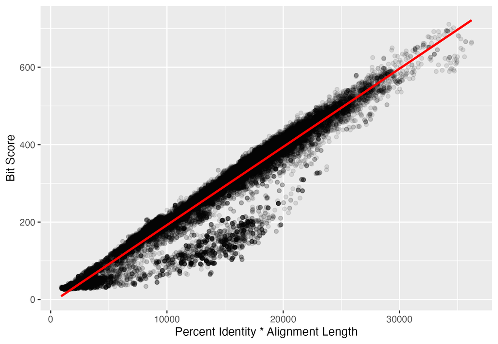

**Q10**. Can you generate a similar plot with `-log(evalue)` on the y-axis? Why do we typically work with -log values in this case? Note that an E-value of exactly 0 gives `Inf` here, so those points will be dropped from your plot.

**TipOPTIONAL Extension**

### Install R and RStudio on AWS!

If you want to analyze your data further on the remote machine (and why not, it is likely bigger and faster after all) then we need to first install the software you want to use for the analysis you have in mind. The following section demonstrates how to install R and RStudio on your remote machine

#### 10A. Install R

The following command installs R (`r-base`) along with `gdebi-core`, a small tool that we will use in the next step to install RStudio.

> **N.B.** Make sure you are working on your remote AWS machine and not your local machine. To make sure try the command `whoami` which will tell you your login name. It should be `ubuntu` if your terminal session is connected to AWS.

```
On AWS
```

```bash
sudo apt-get update && sudo apt-get -y install gdebi-core r-base
```

#### 10B. Install RStudio

After that finishes, download and install [RStudio Server](https://posit.co/download/rstudio-server/), note there is likely a newer version detailed on the Posit website:

```
On AWS
```

```bash
wget https://s3.amazonaws.com/rstudio-ide-build/server/jammy/amd64/rstudio-server-2026.04.1-420-amd64.deb
sudo gdebi rstudio-server-2026.04.1-420-amd64.deb
```

You can double check with:

```
On AWS
```

```bash
rstudio-server status
```

Push ‘q’ to exit and note that you should see a line saying *“Active: active (running)”*.

#### 10C. Figure out your machines Web address to connect to.

Because we’re using the cloud to run things, everyone will have a different computer that they’re running RStudio on. We will use YOUR specific machines IP address to access YOUR specific RStudio server.

If you have forgotten your IP address you can find it out like so:

```
On AWS
```

```bash
curl ifconfig.me
```

This should print-out your public IP address that will look something like `54.200.207.12`. Lets assign this to a variable (called `myip` in this case) and use that to print out the web address you will use to access YOUR server:

```
On AWS
```

```bash
myip=$(curl ifconfig.me)
echo My RStudio Web server is running at: http://$myip:8787/
```

After running this, copy/paste the URL into your Web browser; you should see login page. Enter the username `ubuntu`. Unfortunately, we have not setup a password yet so you will need to return to the terminal and run:

```
On AWS
```

```bash
sudo passwd ubuntu
```

to change your password for this instance.

You will be prompted to enter a new password:

```
New password:
Retype new password:
```

but note that **the text will not echo to the screen** (because it’s a password!)

Return to the browser login page and enter the username: ubuntu and your new password that you just set. Note this will not change the global AWS login info (i.e. it only affects this instance).

**Page won’t load?** RStudio Server listens on port 8787, which must be allowed by your instance’s security group. If it is not, or if you would rather not send your new password over an unencrypted `http` connection, you can reach RStudio through your secure ssh connection instead. In a new terminal on your laptop (with `KEY` and `SERVER` set as in Section 8) run:

```
On your laptop
```

```bash
ssh -i $KEY -L 8787:localhost:8787 $SERVER
```

Leave that window open and point your browser at http://localhost:8787/.

Once RStudio is up and running, we’ll give you a quick tour of the RStudio Web interface, but essentially it is much the same as the Desktop version of RStudio that we have been using up till now. The big difference is that this RStudio is not running on your laptop but rather in the cloud ;-)

Now render your quarto document and transfer everything back to **YOUR LOCAL** computer using **scp** as demonstrated in section 8 above.

```
On your laptop
```

```bash
scp -i $KEY -r "$SERVER:~/work/*" .
```

The quotes here matter: without them your *local* shell will try to expand the `*` itself before `scp` ever sees it (and on a Mac will stop with a “no matches found” error). Be aware that this copies *everything* in `work`, including the large sequence files and BLAST database. To copy just your results you could use `"$SERVER:~/work/*.tsv"` instead.

## Notes:

- Be sure to render your lab report and upload to gradescope..
- If you are done you can **STOP** your AWS instance so we are not charged for it any longer. Go to the AWS console page (you will likely need to login again from https://awsed.ucsd.edu/ ) and select your instance then click “**Instance State**” > “**Stop Instance**”.
- Note you can execute multiple commands at a time (e.g. separated by `;` or `&&`).

**Things for Barry to mention and discuss**:

- `blastp` options and -help.
- command line options, more generally - why so many?
- when you **terminate** a VM, you lose all your data (a **stopped** instance keeps its disk)
- what computer(s) is this all happening on?